# HW4_ozbelen_sena_1901042601_code

```python
import numpy as np
import matplotlib.pyplot as plt
from sklearn.preprocessing import StandardScaler
from keras.datasets import mnist
from pyclustering.cluster.kmeans import kmeans, kmeans_visualizer
from pyclustering.cluster.center_initializer import kmeans_plusplus_initializer
from pyclustering.utils import distance_metric, type_metric
import pandas as pd
from sklearn.metrics import confusion_matrix, accuracy_score
from sklearn.neighbors import KNeighborsClassifier
from sklearn.model_selection import train_test_split
```

This code uses pyclustering to perform K-means. It might have an error with center_initializer.py file of the library. Remove numpy in line 234 when encountered.

Load the dataset and perform preprocessing for the pixel values

```python
# Load the MNIST dataset from Keras
(x_train, y_train), (x_test, y_test) = mnist.load_data()

# Combine training and testing data for cross-validation
x_all = np.concatenate((x_train, x_test))
y_all = np.concatenate((y_train, y_test))

# Flatten the images and standardize the pixel values
x_all_flat = x_all.reshape(-1, 28 * 28).astype(np.float32)

# Standardize the data
scaler = StandardScaler()
x_all_scaled = scaler.fit_transform(x_all_flat)
```

Define the distances

```python
def euclidean_distance(point1, point2):
    return np.linalg.norm(point1 - point2)

def cosine_distance(point1, point2):
    return 1 - np.dot(point1, point2) / (np.linalg.norm(point1) * np.linalg.norm(point2))

def manhattan_distance(point1, point2):
    return np.sum(np.abs(point1 - point2))
```

Define the function to create count table

```python
def create_count_table(y_train, labels):

    df = pd.DataFrame({'True_Label': y_train, 'Cluster_Label': labels})

    count_table = pd.crosstab(df['Cluster_Label'], df['True_Label'])

    return count_table
```

Define the function to assign the labels of the clusters by finding maximum values

```python
# Function to assign labels to clusters based on the majority class in each cluster
def assign_labels_to_clusters(count_table):
    num_clusters, num_labels = count_table.shape
    cluster_labels = [None] * num_clusters  # Initialize an array to hold cluster labels
    used_labels = set()  # Initialize a set to track used labels

    # Iterate until all clusters are labeled
    while None in cluster_labels and len(used_labels) < num_labels:
        # Find the maximum value in the count table and its indices
        max_value = -1
        max_i = -1
        max_j = -1
        for i in range(num_clusters):
            for j in range(num_labels):
                if count_table.iloc[i, j] > max_value and cluster_labels[i] is None and j not in used_labels:
                    max_value = count_table.iloc[i, j]
                    max_i = i
                    max_j = j

        # If a valid maximum was found, assign the label
        if max_i != -1 and max_j != -1:
            cluster_labels[max_i] = max_j  # Assign label j to cluster i
            used_labels.add(max_j)  # Add label j to the set of used labels

    return cluster_labels
```

Use Euclidean distance to perform K-means. It uses 80% of data as training and 20% of data as testing. This is done 5 times.

```
----------------------------------------------
Table 1 (Cluster Label vs True Label):
True_Label        0     1     2     3     4     5     6     7     8     9
Cluster_Label
0               739    92   271   588  1633  2118    66  2116  2180  1684
1                 0     0     0     0     0     0     0     2     0     2
2              3636     0   113    25    82    42   264    22    60    56
3                12     1   114   193  2984   268    19  2892   274  3193
4                 0     0     1     0     0     0     0     0     0     0
5                 0     0     1     0     0     0     0     0     0     0
6               767    15  1024  3950     5  1810    58    17  1644    84
7                 0     0     0     2     0     0     0     0     0     1
8                48  6148   615   716   627   676   676   738  1267   506
9               358    21  3471   234   198   126  4397     3    43    12

Cluster Labels: [8, 7, 0, 9, 2, 4, 3, 5, 1, 6]
----------------------------------------------
----------------------------------------------
Table 2 (Cluster Label vs True Label):
True_Label        0     1     2     3     4     5     6     7     8     9
Cluster_Label
0                64  6094   584   762   553   858   666   465  1373   324
1              1424   143  1066  1287   192  2001   249    99  1815    64
2                 0     0     0     0     0     0     0    38     0     0
3                54     6    72   144  2698   436     5  3894   613  3208
4               225    20  2713   148   171    90  4178     6    28     8
5              3165     0    67    10    50    35   260    17    43    37
6                 0     0     0     0     0     0     1     0     0     0
7                 0     0     4     0     0     0    56     0     0     0
8               621    12  1041  3238     6  1450    51    24  1432    75
9                 7     2    63   119  1859   170    14  1247   164  1822

Cluster Labels: [1, 5, 8, 7, 6, 0, 9, 2, 3, 4]
----------------------------------------------
----------------------------------------------
Table 3 (Cluster Label vs True Label):
True_Label        0     1     2     3     4     5     6     7     8     9
Cluster_Label
0                33  6209   649   490   534   675   508   549  1077   342
1              3538     0    90    19    50    32   183    22    46    47
```

[output cut: 31 more lines]

```
Cluster_Label
0                63  6098   582   730   474   897   653   435  1385   292
1                45     6    88   178  3007   417    12  1445   455  2844
2                11     0    44    74   369    53     8   788    72   381
3                 7     3    28    72  1325   214     0  3031   307  1872
4              3159     0    66     8    53    29   254    16    40    33
5              1491   137  1100  1343   152  2007   257    50  1880    44
6                 0     0     0     1     0     0     0     0     0     0
7               207    20  2615   141   135    87  4249     5    24     7
8                 0     1     0     0     0     0     0     0     0     0
9               577    12  1087  3161    14  1336    47    20  1305    65

Cluster Labels: [1, 4, 9, 7, 0, 5, 2, 6, 8, 3]
----------------------------------------------
Average Accuracy - Training: 0.44
```

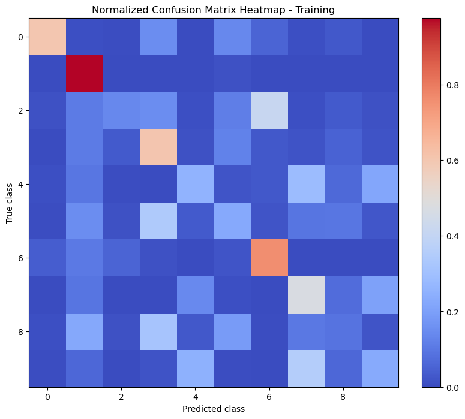

```
Average Accuracy - Testing: 0.45
```

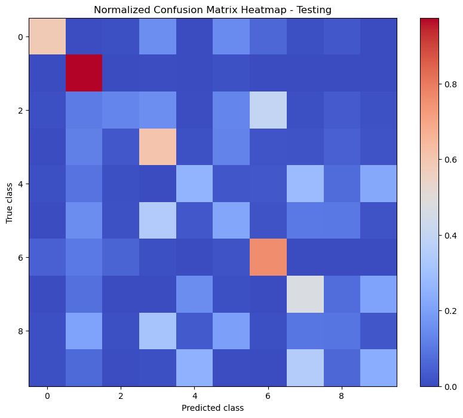

```python
accuracies_train = []
confusion_matrices_train = []
accuracies_test = []
confusion_matrices_test = []
count = 0

for i in range(5):

    # Split the data into 80% training and 20% testing
    x_train_split, x_test_split, y_train_split, y_test_split = train_test_split(x_all_scaled, y_all, test_size=0.2, random_state=42)

    # Define the distance metric
    distance_metric_choice = distance_metric(type_metric.USER_DEFINED, func=euclidean_distance)

    # Number of components
    num_clusters = 10

    # Initialize the centers for KMeans using KMeans++
    initial_centers = kmeans_plusplus_initializer(x_train_split, num_clusters).initialize()

    # Create a KMeans object using pyclustering with the chosen distance metric
    kmeans_instance = kmeans(x_train_split, initial_centers, metric=distance_metric_choice)

    # Perform KMeans clustering
    kmeans_instance.process()

    # Retrieve the cluster labels and centers
    clusters = kmeans_instance.get_clusters()
    centers = kmeans_instance.get_centers()

    # Create a list of labels for each data point
    labels = np.zeros(x_train_split.shape[0], dtype=int)
    for cluster_id, cluster_points in enumerate(clusters):
        for point_index in cluster_points:
            labels[point_index] = cluster_id

    # Call count table function
    count_table = create_count_table(y_train_split, labels)
    print("----------------------------------------------")
    print(f'Table {count+1} (Cluster Label vs True Label):')
    print(count_table)

    # Call assigning function
    cluster_labels = assign_labels_to_clusters(count_table)

    print("\nCluster Labels:", cluster_labels)
    print("----------------------------------------------")
    # Create a list of assigned labels for each data point
    labels_assigned = np.zeros(x_train_split.shape[0], dtype=int)
    for cluster_id, cluster_points in enumerate(clusters):
        for point_index in cluster_points:
            labels_assigned[point_index] = cluster_labels[cluster_id]

    # Calculate the normalized confusion matrix
    conf_matrix_train = confusion_matrix(y_train_split, labels_assigned, normalize='true')
    confusion_matrices_train.append(conf_matrix_train)

    # Calculate the accuracy
    accuracy_train = accuracy_score(y_train_split, labels_assigned)
    accuracies_train.append(accuracy_train)


    #### TEST DATA ####

    # Use 1-NN to classify each data point in the test set
    knn_classifier = KNeighborsClassifier(n_neighbors=1)

    # Fit the 1-NN classifier using the cluster centers as training data
    knn_classifier.fit(centers, cluster_labels)

    # Predict the cluster for each test data point
    predicted_clusters = knn_classifier.predict(x_test_split)

    # Calculate the normalized confusion matrix
    conf_matrix_test = confusion_matrix(y_test_split, predicted_clusters, normalize='true')
    confusion_matrices_test.append(conf_matrix_test)

    # Calculate the accuracy
    accuracy_test = accuracy_score(y_test_split, predicted_clusters)
    accuracies_test.append(accuracy_test)

    count += 1



# calculate average accuracy
average_accuracy_train = np.mean(accuracies_train)

# calculate average confusion matrix
average_conf_matrix_train = np.mean(confusion_matrices_train, axis=0)

# print the result
print(f'Average Accuracy - Training: {average_accuracy_train:.2f}')

# create a heatmap for the normalized confusion matrix
plt.figure(figsize=(10, 8))

cmap = plt.get_cmap('coolwarm')
heatmap = plt.imshow(average_conf_matrix_train, cmap=cmap)
plt.colorbar(heatmap)
plt.xlabel('Predicted class')
plt.ylabel('True class')
plt.title('Normalized Confusion Matrix Heatmap - Training')

# show the plot
plt.show()



# calculate average accuracy
average_accuracy_test = np.mean(accuracies_test)

# calculate average confusion matrix
average_conf_matrix_test = np.mean(confusion_matrices_test, axis=0)

# print the result
print(f'Average Accuracy - Testing: {average_accuracy_test:.2f}')

# create a heatmap for the normalized confusion matrix
plt.figure(figsize=(10, 8))

cmap = plt.get_cmap('coolwarm')
heatmap = plt.imshow(average_conf_matrix_test, cmap=cmap)
plt.colorbar(heatmap)
plt.xlabel('Predicted class')
plt.ylabel('True class')
plt.title('Normalized Confusion Matrix Heatmap - Testing')

# show the plot
plt.show()
```

The accuracy values for both training and testing are almost the same. And, their confusion matrices are also the same. Therefore, we can say that training and testing parts give almost the same results. The average accuracy is very low for this case. It can cluster the class 1 better. Also, the classes 0, 3, 6 and 7 are better than the rest.

Use Manhattan distance to perform K-means

```
----------------------------------------------
Table 1 (Cluster Label vs True Label):
True_Label        0     1     2     3     4     5     6     7     8     9
Cluster_Label
0               418  6256  1834  2420  4573  3367   699  5507  4462  4852
1                99     1   146  2834     0  1237     5     3   742    52
2               627    15   484   146   244   213  4025     2    98    17
3                 1     0     0     7   668    27     2   241    19   566
4                 9     0     1     1    15     2   656     0     1     0
5                 2     5  1434    17     0     1     4     2     5     0
6                 0     0     0     0     1     0     0     1     0     0
7                 7     0  1619   198     9     2     1     3    28     1
8              2646     0    89    81    15   151    47    24    81    36
9              1751     0     3     4     4    40    41     7    32    14

Cluster Labels: [1, 3, 6, 4, 9, 8, 7, 2, 0, 5]
----------------------------------------------
----------------------------------------------
Table 2 (Cluster Label vs True Label):
True_Label        0     1     2     3     4     5     6     7     8     9
Cluster_Label
0               629  6267  3054  3430  1730  3479  1237  1922  4449  1658
1                10     0     1     1    11     1   657     0     1     1
2                 2     3  1311    12     0     1     3     1     3     0
3                 0     0     0     2   304    12     0    42    15   251
4               464     5   688    59   139   103  3463     1    42     8
5               106     1    83  1947     1   980     6     2   537    38
6                 0     0     0     1     0     0     0     0     0     0
7              2164     0     5     3     4    27    41     7    27    13
8                38     1    79   123  3327   332    25  3807   313  3542
9              2147     0   389   130    13   105    48     8    81    27

Cluster Labels: [1, 8, 2, 4, 6, 3, 9, 0, 7, 5]
----------------------------------------------
----------------------------------------------
Table 3 (Cluster Label vs True Label):
True_Label        0     1     2     3     4     5     6     7     8     9
Cluster_Label
0                86     0   141  1673     1   823     8     2   467    34
1              1738     0     3     5     6    28    99     7    27    10
```

[output cut: 31 more lines]

```
Cluster_Label
0              1605     0     4    31     3   158    30     7    77    17
1               167     7   381   290  4700  1399    75  4333  1192  4848
2               671     8   432    83   137   171  3954     1    93     7
3              2772     0   119    84     8   131    44     5    79    28
4                 0     0     0     9   455    29     1    33    41   350
5                14     0     4     1    10     3   661     0     1     1
6                 0     0     0     0     0     0     0     2     0     1
7               327  6262  2783  5148   210  3148   714   410  3980   279
8                 4     0  1884    50     4     1     1     3     5     0
9                 0     0     3    12     2     0     0   996     0     7

Cluster Labels: [5, 9, 6, 0, 4, 3, 8, 1, 2, 7]
----------------------------------------------
Average Accuracy - Training: 0.36
```

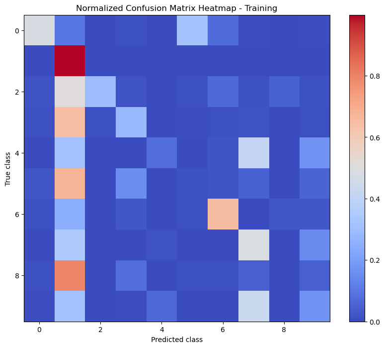

```
Average Accuracy - Testing: 0.39
```

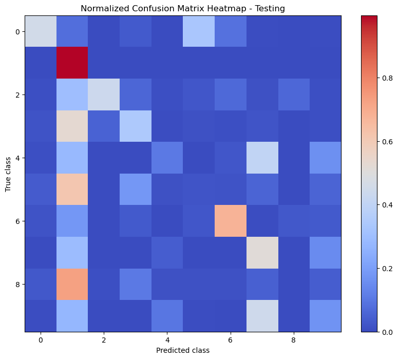

```python
accuracies_train = []
confusion_matrices_train = []
accuracies_test = []
confusion_matrices_test = []
count = 0

for i in range(5):

    # Split the data into 80% training and 20% testing
    x_train_split, x_test_split, y_train_split, y_test_split = train_test_split(x_all_scaled, y_all, test_size=0.2, random_state=42)

    # Define the distance metric
    distance_metric_choice = distance_metric(type_metric.USER_DEFINED, func=manhattan_distance)

    # Number of components
    num_clusters = 10

    # Initialize the centers for KMeans using KMeans++
    initial_centers = kmeans_plusplus_initializer(x_train_split, num_clusters).initialize()

    # Create a KMeans object using pyclustering with the chosen distance metric
    kmeans_instance = kmeans(x_train_split, initial_centers, metric=distance_metric_choice)

    # Perform KMeans clustering
    kmeans_instance.process()

    # Retrieve the cluster labels and centers
    clusters = kmeans_instance.get_clusters()
    centers = kmeans_instance.get_centers()

    # Create a list of labels for each data point
    labels = np.zeros(x_train_split.shape[0], dtype=int)
    for cluster_id, cluster_points in enumerate(clusters):
        for point_index in cluster_points:
            labels[point_index] = cluster_id

    # Call count table function
    count_table = create_count_table(y_train_split, labels)
    print("----------------------------------------------")
    print(f'Table {count+1} (Cluster Label vs True Label):')
    print(count_table)

    # Call assigning function
    cluster_labels = assign_labels_to_clusters(count_table)

    print("\nCluster Labels:", cluster_labels)
    print("----------------------------------------------")
    # Create a list of assigned labels for each data point
    labels_assigned = np.zeros(x_train_split.shape[0], dtype=int)
    for cluster_id, cluster_points in enumerate(clusters):
        for point_index in cluster_points:
            labels_assigned[point_index] = cluster_labels[cluster_id]

    # Calculate the normalized confusion matrix
    conf_matrix_train = confusion_matrix(y_train_split, labels_assigned, normalize='true')
    confusion_matrices_train.append(conf_matrix_train)

    # Calculate the accuracy
    accuracy_train = accuracy_score(y_train_split, labels_assigned)
    accuracies_train.append(accuracy_train)


    #### TEST DATA ####

    # Use 1-NN to classify each data point in the test set
    knn_classifier = KNeighborsClassifier(n_neighbors=1)

    # Fit the 1-NN classifier using the cluster centers as training data
    knn_classifier.fit(centers, cluster_labels)

    # Predict the cluster for each test data point
    predicted_clusters = knn_classifier.predict(x_test_split)

    # Calculate the normalized confusion matrix
    conf_matrix_test = confusion_matrix(y_test_split, predicted_clusters, normalize='true')
    confusion_matrices_test.append(conf_matrix_test)

    # Calculate the accuracy
    accuracy_test = accuracy_score(y_test_split, predicted_clusters)
    accuracies_test.append(accuracy_test)

    count += 1



# calculate average accuracy
average_accuracy_train = np.mean(accuracies_train)

# calculate average confusion matrix
average_conf_matrix_train = np.mean(confusion_matrices_train, axis=0)

# print the result
print(f'Average Accuracy - Training: {average_accuracy_train:.2f}')

# create a heatmap for the normalized confusion matrix
plt.figure(figsize=(10, 8))

cmap = plt.get_cmap('coolwarm')
heatmap = plt.imshow(average_conf_matrix_train, cmap=cmap)
plt.colorbar(heatmap)
plt.xlabel('Predicted class')
plt.ylabel('True class')
plt.title('Normalized Confusion Matrix Heatmap - Training')

# show the plot
plt.show()



# calculate average accuracy
average_accuracy_test = np.mean(accuracies_test)

# calculate average confusion matrix
average_conf_matrix_test = np.mean(confusion_matrices_test, axis=0)

# print the result
print(f'Average Accuracy - Testing: {average_accuracy_test:.2f}')

# create a heatmap for the normalized confusion matrix
plt.figure(figsize=(10, 8))

cmap = plt.get_cmap('coolwarm')
heatmap = plt.imshow(average_conf_matrix_test, cmap=cmap)
plt.colorbar(heatmap)
plt.xlabel('Predicted class')
plt.ylabel('True class')
plt.title('Normalized Confusion Matrix Heatmap - Testing')

# show the plot
plt.show()
```

Manhattan distance works poorly when the accuracy values are considered. The best class is 1 for this case as well. It predicts a lot of data entries as the class 1 too which is not expected from a proper model.

Use Cosine distance to perform K-means

```
----------------------------------------------
Table 1 (Cluster Label vs True Label):
True_Label        0     1     2     3     4     5     6     7     8     9
Cluster_Label
0                23  6021   385   421   285   621   290   345   894   200
1               363    19   548    86   104   118  4071     0    39     5
2               252    15   195  3214     0  1451    34     1  1625    78
3                 2     0    72   112    22    13     2  2479    23    89
4              4170     0   300    55   154   129   288    35   111    66
5                82    13  3001   460    28   131   636    21   107     8
6               613   192   938  1055   120  1753   142    46  1646    23
7                 7     5    23    71  1174   276     0  2245   363  1539
8                30     6   116   148  1195   294    13   196   334   959
9                18     6    32    86  2447   254     4   422   326  2571

Cluster Labels: [1, 6, 3, 7, 0, 2, 5, 8, 4, 9]
----------------------------------------------
----------------------------------------------
Table 2 (Cluster Label vs True Label):
True_Label        0     1     2     3     4     5     6     7     8     9
Cluster_Label
0                10  3658   159   547   341   338   193   335   357   322
1                87    23    27    27   690  2093    50   191  1195   128
2                60    13  2845   127    85    74   867    18    74    26
3              4047     0   183    35   225   106   287    59    97   109
4                 3     1    80   121  2487   193     0  1427   187  2362
5                17  2544   400   148   296    60    98   266  1299   107
6                21     5    29    97  1238    80     0  3460   241  2381
7               433    12   259    55   154   136  3933     0    48    10
8               670    15  1345  1508     9   526    28    21   488    15
9               212     6   283  3043     4  1434    24    13  1482    78

Cluster Labels: [1, 5, 2, 0, 4, 8, 7, 6, 9, 3]
----------------------------------------------
----------------------------------------------
Table 3 (Cluster Label vs True Label):
True_Label        0     1     2     3     4     5     6     7     8     9
Cluster_Label
0                22  6062   448   388   314   292   300   274   853   146
1              4147     0   119    35   169   115   336    49   103    81
```

[output cut: 31 more lines]

```
Cluster_Label
0                16     2    18    78  1329   306     0  2908   352  1944
1                11  3963   205   435   258   466   216   389   364   265
2               234     6   126  3176     1  1544    27     3  1573    88
3                51    14  2930   483    47   164   498    18   151    14
4               391    14   420    72   114   114  4049     0    44     7
5                 9     0    49    85  2586   254     3   798   255  2537
6                11     2   131   213   568   110     9  1433   160   517
7              1225    11  1077   933   122  1664   114    24   996    23
8                24  2265   475   192   283   282   107   188  1448    65
9              3588     0   179    41   221   136   457    29   125    78

Cluster Labels: [7, 1, 3, 2, 6, 4, 9, 5, 8, 0]
----------------------------------------------
Average Accuracy - Training: 0.51
```

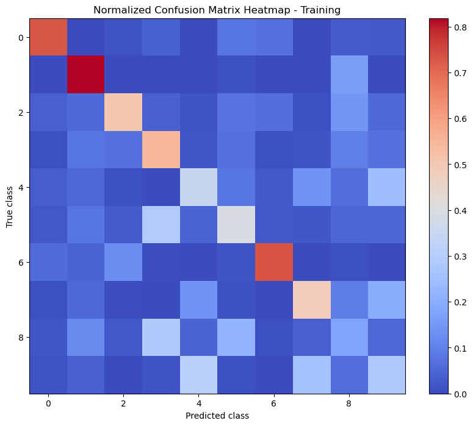

```
Average Accuracy - Testing: 0.50
```

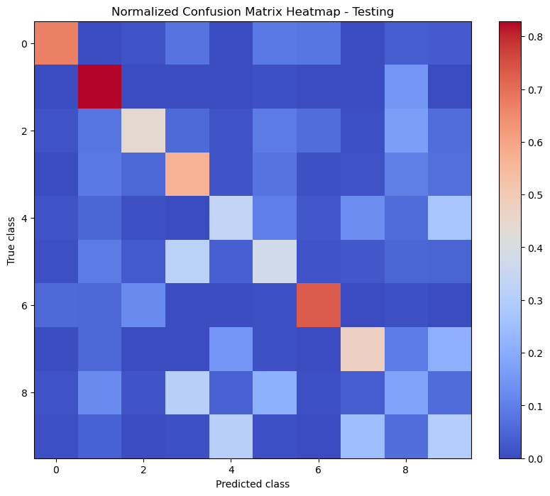

```python
accuracies_train = []
confusion_matrices_train = []
accuracies_test = []
confusion_matrices_test = []
count = 0

for i in range(5):

    # Split the data into 80% training and 20% testing
    x_train_split, x_test_split, y_train_split, y_test_split = train_test_split(x_all_scaled, y_all, test_size=0.2, random_state=42)

    # Define the distance metric
    distance_metric_choice = distance_metric(type_metric.USER_DEFINED, func=cosine_distance)

    # Number of components
    num_clusters = 10

    # Initialize the centers for KMeans using KMeans++
    initial_centers = kmeans_plusplus_initializer(x_train_split, num_clusters).initialize()

    # Create a KMeans object using pyclustering with the chosen distance metric
    kmeans_instance = kmeans(x_train_split, initial_centers, metric=distance_metric_choice)

    # Perform KMeans clustering
    kmeans_instance.process()

    # Retrieve the cluster labels and centers
    clusters = kmeans_instance.get_clusters()
    centers = kmeans_instance.get_centers()

    # Create a list of labels for each data point
    labels = np.zeros(x_train_split.shape[0], dtype=int)
    for cluster_id, cluster_points in enumerate(clusters):
        for point_index in cluster_points:
            labels[point_index] = cluster_id

    # Call count table function
    count_table = create_count_table(y_train_split, labels)
    print("----------------------------------------------")
    print(f'Table {count+1} (Cluster Label vs True Label):')
    print(count_table)

    # Call assigning function
    cluster_labels = assign_labels_to_clusters(count_table)

    print("\nCluster Labels:", cluster_labels)
    print("----------------------------------------------")
    # Create a list of assigned labels for each data point
    labels_assigned = np.zeros(x_train_split.shape[0], dtype=int)
    for cluster_id, cluster_points in enumerate(clusters):
        for point_index in cluster_points:
            labels_assigned[point_index] = cluster_labels[cluster_id]

    # Calculate the normalized confusion matrix
    conf_matrix_train = confusion_matrix(y_train_split, labels_assigned, normalize='true')
    confusion_matrices_train.append(conf_matrix_train)

    # Calculate the accuracy
    accuracy_train = accuracy_score(y_train_split, labels_assigned)
    accuracies_train.append(accuracy_train)


    #### TEST DATA ####

    # Use 1-NN to classify each data point in the test set
    knn_classifier = KNeighborsClassifier(n_neighbors=1)

    # Fit the 1-NN classifier using the cluster centers as training data
    knn_classifier.fit(centers, cluster_labels)

    # Predict the cluster for each test data point
    predicted_clusters = knn_classifier.predict(x_test_split)

    # Calculate the normalized confusion matrix
    conf_matrix_test = confusion_matrix(y_test_split, predicted_clusters, normalize='true')
    confusion_matrices_test.append(conf_matrix_test)

    # Calculate the accuracy
    accuracy_test = accuracy_score(y_test_split, predicted_clusters)
    accuracies_test.append(accuracy_test)

    count += 1



# calculate average accuracy
average_accuracy_train = np.mean(accuracies_train)

# calculate average confusion matrix
average_conf_matrix_train = np.mean(confusion_matrices_train, axis=0)

# print the result
print(f'Average Accuracy - Training: {average_accuracy_train:.2f}')

# create a heatmap for the normalized confusion matrix
plt.figure(figsize=(10, 8))

cmap = plt.get_cmap('coolwarm')
heatmap = plt.imshow(average_conf_matrix_train, cmap=cmap)
plt.colorbar(heatmap)
plt.xlabel('Predicted class')
plt.ylabel('True class')
plt.title('Normalized Confusion Matrix Heatmap - Training')

# show the plot
plt.show()



# calculate average accuracy
average_accuracy_test = np.mean(accuracies_test)

# calculate average confusion matrix
average_conf_matrix_test = np.mean(confusion_matrices_test, axis=0)

# print the result
print(f'Average Accuracy - Testing: {average_accuracy_test:.2f}')

# create a heatmap for the normalized confusion matrix
plt.figure(figsize=(10, 8))

cmap = plt.get_cmap('coolwarm')
heatmap = plt.imshow(average_conf_matrix_test, cmap=cmap)
plt.colorbar(heatmap)
plt.xlabel('Predicted class')
plt.ylabel('True class')
plt.title('Normalized Confusion Matrix Heatmap - Testing')

# show the plot
plt.show()
```